# Primer of Ecology with R: chapter 1

Molly, Jacob, Mireia, Erin, Casey

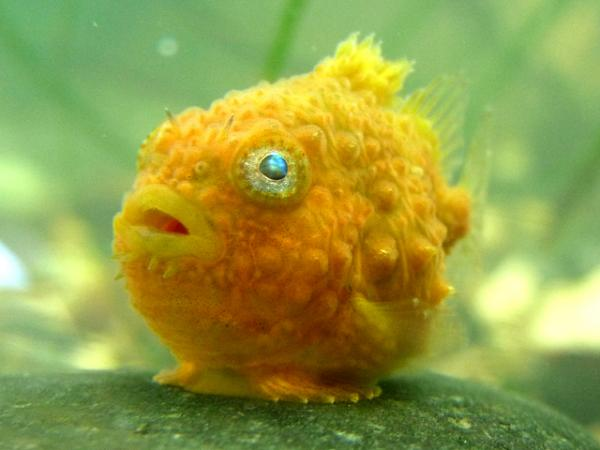

```r
knitr::opts_chunk$set(fig.width = 6, fig.height = 4, # fig.path = 'Figs/lumpsucker',
                      echo = TRUE, message = FALSE, warning = FALSE)

library(tidyverse)
library(RColorBrewer)

### The book has an R package!
library(primer) # install.packages('primer')
```

# Chapter 1

## 1.3 Exploring Population Growth

#### Simple Graphing of Population Size (Fig. 1.3)

Here we create two vectors: population size, $N$, and years. Using `c()` allows us to create an arbitrary vector, and the colon, `:`, provides a sequence of consecutive integers.

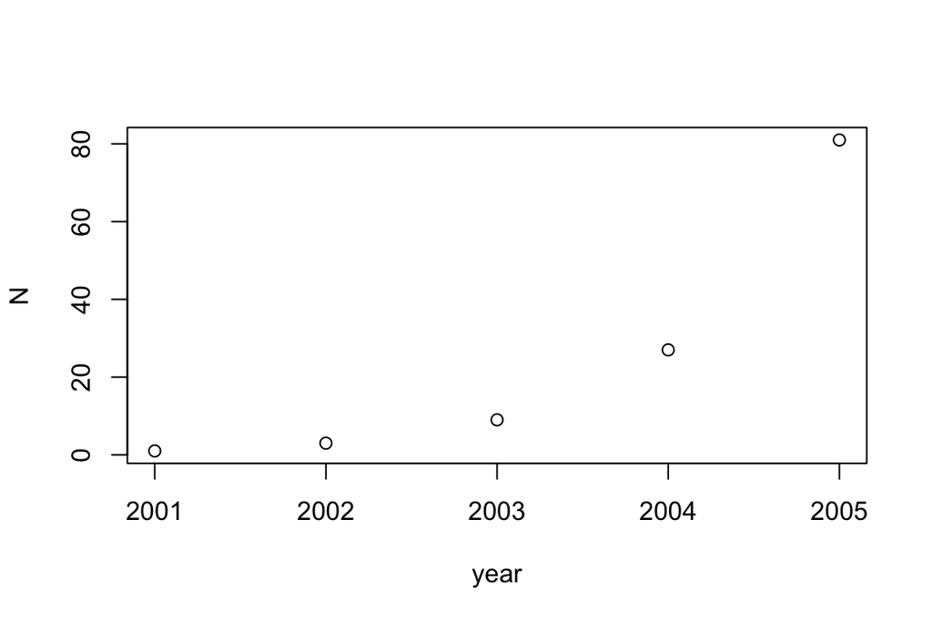

```r
### Original version
N <- c(1, 3, 9, 27, 81)
year <- 2001:2005
plot(year, N)
```

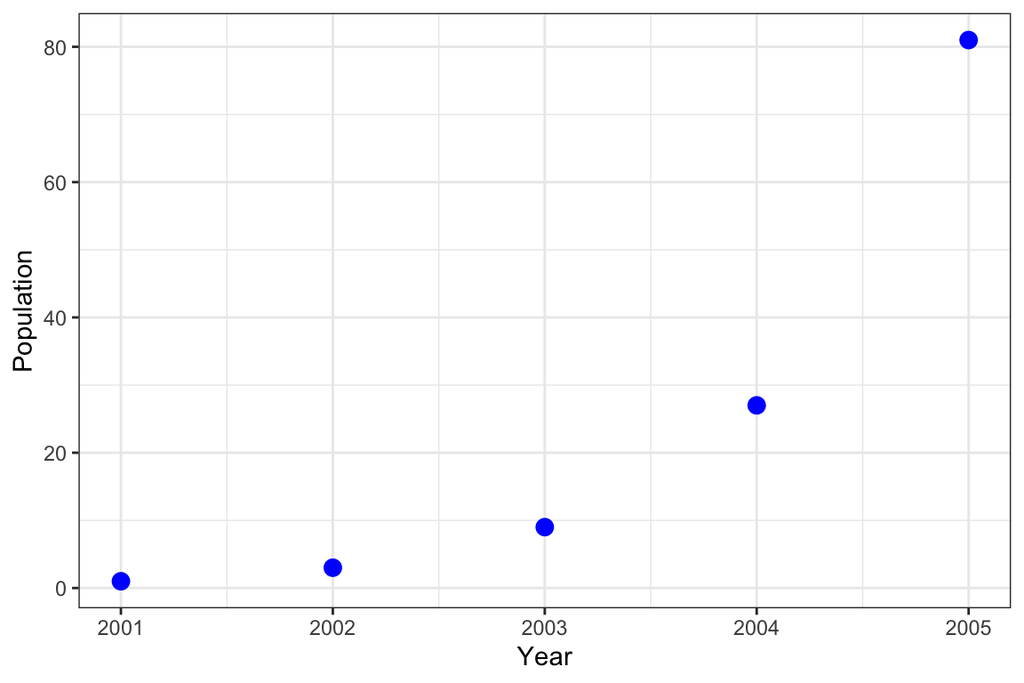

```r
### Casey's version
exp_growth <- data.frame(N = c(1, 3, 9, 27, 81),
                         year = 2001:2005)
ggplot(exp_growth, aes(x = year, y = N)) +
  theme_bw() +
  geom_point(color = 'blue', size = 3) +
  labs(x = 'Year', y = 'Population')
```

The lily population (Fig. 1.3) increases by a different amount each year. What about proportions — does it increase by a different proportion each year? Let’s divide each year’s population size by the previous year’s size, that is, perform $N_{t+1}/N_t$ for all $t$, where $t$ is any particular point in time, and $t + 1$ is the next point in time. For $N$, that amounts to 3/1, 9/3, . . . . What do we notice?

#### Vectorized math

Here we divide each element of one vector (the second through fifth element of $N$) by each element of another vector (the first through fourth elements of $N$).

```r
rates = N[2:5]/N[1:4]
rates
```

```
## [1] 3 3 3 3
```

```r
# [1] 3 3 3 3
```

### 1.3.1 Projecting population size

Here we calculate population sizes for 10 time points beyond the initial. First we assign values for $N_0$, $\lambda$, and time.

```r
N0 <- 1
lambda <- 2
time <- 0:10
```

Next we calculate $N_t$ directly using our general formula.

```r
Nt <- N0 * lambda^time
Nt
```

```
##  [1]    1    2    4    8   16   32   64  128  256  512 1024
```

```r
# [1] 1 2 4 8 16 32 64 128 256 5121024
```

### 1.3.2 Effects of Initial Population Size

We first set up several different initial values, provide a fixed $\lambda$, and set times from zero to 4.

```r
N0 <- c(10, 20, 30)
lambda <- 2
time <- 0:4
```

We calculate population sizes at once using `sapply` to *apply* a function (`n*lambda^time`) to each element of the first argument (each element of `N0`).

```r
Nt.s <- sapply(N0, function(n) n * lambda^time)
Nt.s
```

```
##      [,1] [,2] [,3]
## [1,]   10   20   30
## [2,]   20   40   60
## [3,]   40   80  120
## [4,]   80  160  240
## [5,]  160  320  480
```

```r
#      [,1] [,2] [,3]
# [1,]   10   20   30
# [2,]   20   40   60
# [3,]   40   80  120
# [4,]   80  160  240
# [5,]  160  320  480
```

The result is a matrix, and we see $N_0$ in the first row, and each population is in its own column. Note that population 2 is always twice as big as population 1.

#### Graphing a Matrix (Figs. 1.3a, 1.3b)

We can use matplot to plot a matrix vs. a single vector on the X-axis. By default it labels the points according to the number of the column

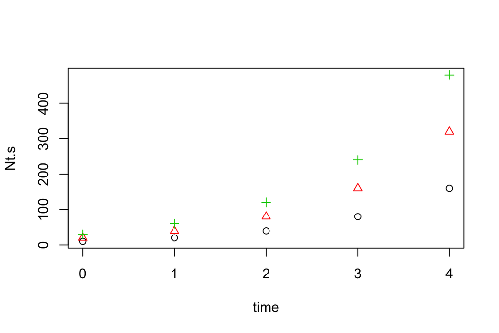

```r
matplot(time, Nt.s, pch = 1:3)
```

We can also plot it with a log scale on the y-axis.

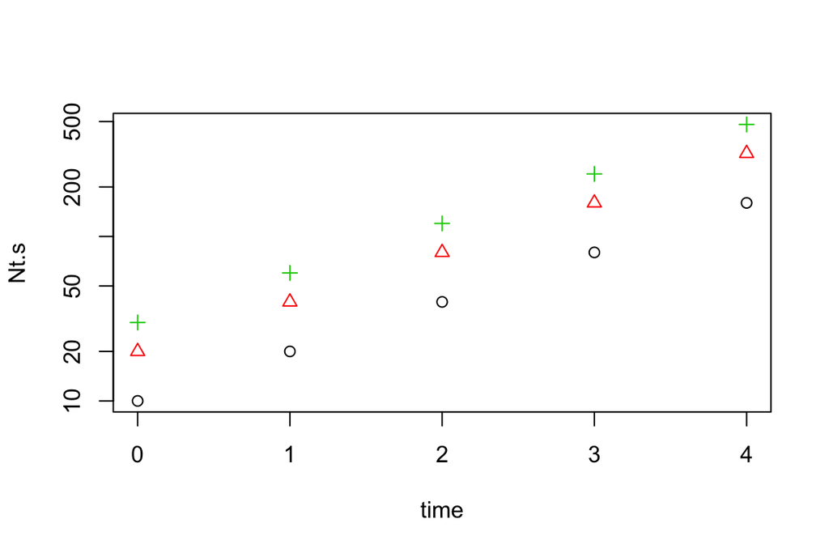

```r
matplot(time, Nt.s, log = "y", pch = 1:3)
```

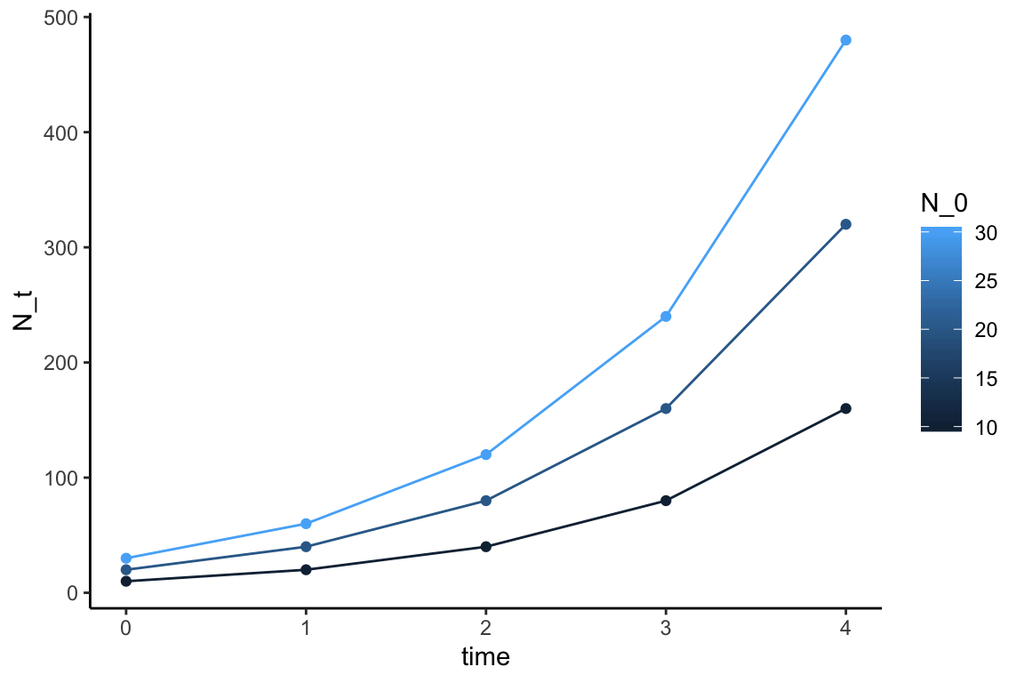

```r
### Casey's version of section 1.3.2:
###   using crossing() to make all combinations of year and starting pop
lambda <- 2
time <- 0:4
N_0  <- c(10, 20, 30)

pop_df <- crossing(time, N_0) %>%
  mutate(N_t = N_0 * lambda ^ time)

ggplot(pop_df, aes(x = time, y = N_t, color = N_0)) +
  theme_classic() +
  geom_line(aes(group = N_0)) +
  geom_point()
```

### 1.3.3 Effects of different per capita growth rates

Here we demonstrate the effects on growth of $\lambda > 1$ and $\lambda < 1$. We set $N_0 = 100$, and time, and then pick three different $\lambda$.

```r
N0 <- 100
time <- 0:3
lambdas <- c(0.5, 1, 1.5)
```

We use `sapply` again to apply the geometric growth function to each $\lambda$. This time, `x` stands for each $\lambda$, which our function then uses to calculate population size. We then plot it, and add a reference line and a little text.

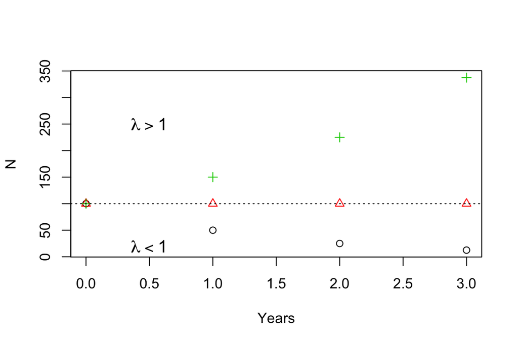

```r
N.all <- sapply(lambdas, function(x) N0 * x^time)
matplot(time, N.all, xlab = "Years", ylab = "N", pch = 1:3)
abline(h = N0, lty = 3)
text(0.5, 250, expression(lambda > 1), cex = 1.2)
text(0.5, 20, expression(lambda < 1), cex = 1.2)
```

The reference line is a *h*orizontal line with the *l*ine *ty*pe dotted. Our text simply indicates the regions of positive and negative growth.

### 1.3.4 Average growth rate

#### Comparing arithmetic and geometric averages (Fig. 1.5)

First we select the number of observed $R$ $(t = 5)$; this will require that we use six years of Song Sparrow data.

```r
t <- 5
data(sparrows)
SS6 <- sparrows[1:(t + 1), ]
```

Next we calculate $\lambda$ for each generation, from $t$ to $t + 1$, and calculate the arithmetic and geometric means.

```r
SSgr <- SS6$Count[2:(t + 1)]/SS6$Count[1:t]
lam.A <- sum(SSgr)/t
lam.G <- prod(SSgr)^(1/t)
```

Now we can plot the data, and the projections based on the two averages (Fig. 1.5).

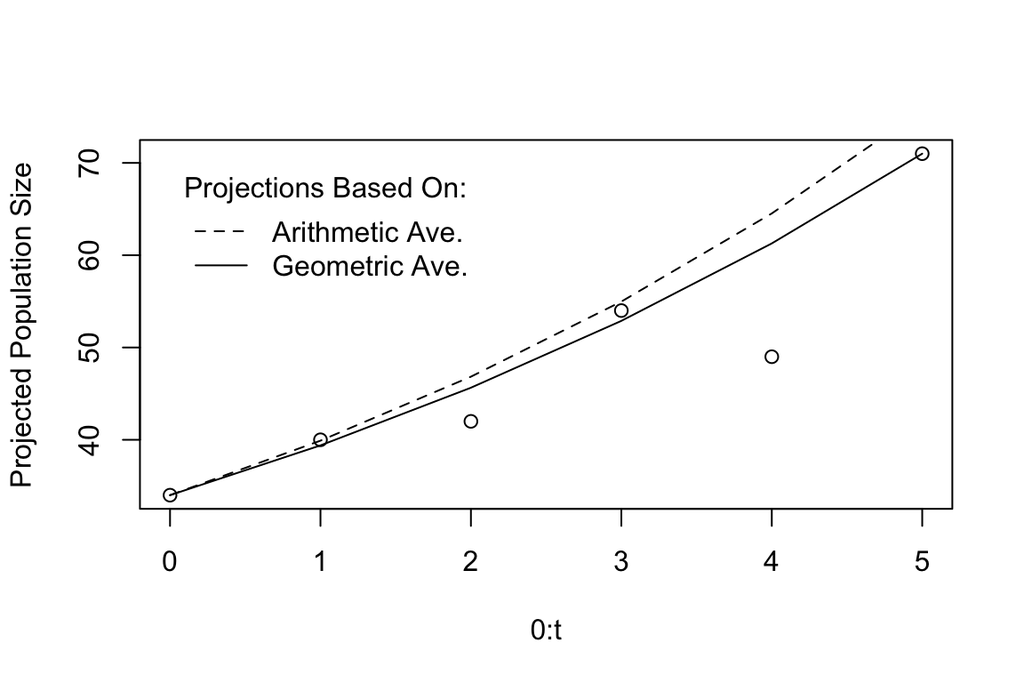

```r
N0 <- SS6$Count[1]
plot(0:t, SS6$Count, ylab = "Projected Population Size")
lines(0:t, N0 * lam.A^(0:t), lty = 2)
lines(0:t, N0 * lam.G^(0:t), lty = 1)
legend(0, 70,
       c("Arithmetic Ave.", "Geometric Ave."),
       title = "Projections Based On:",
       lty = 2:1, bty = "n", xjust = 0)
```

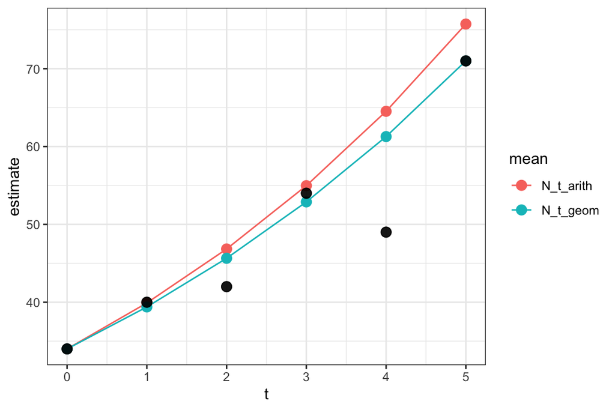

```r
### Casey's version of section 1.3.4
data(sparrows) ### load data from the primer package

### Using the first six years of sparrow data... because that's the portion
### of the data that is basically exponential growth?  let's check a plot:
# ggplot(sparrows, aes(x = Year, y = Count)) +
#   geom_point()
### Kinda looks like it - after year 6 it flattens out

### Calculate the growth rate from year t to year t-1 separately, then average
sparrows_6yr <- sparrows %>%
  setNames(tolower(names(.))) %>% ### I hate capitals in colnames
  mutate(t = 0:(n()-1)) %>%  ### create a t column to use instead of year maybe
  filter(t < 6) %>%
  mutate(lambda = count / lag(count))

l_means <- sparrows_6yr %>%
  filter(!is.na(lambda)) %>%
  summarize(lambda_arth = sum(lambda) / n(),
            lambda_geom = prod(lambda) ^ (1/n()))
### check that they match the base R values: yep!

### for a stochastic simulation we'd need to calculate each year in turn
### but for a deterministic, we can make a dataframe with the N0 column
### and calculate each year by accounting for the amount of time passed
pop_df <- sparrows_6yr %>%
  select(t, count) %>% ### no need for the extra columns
  mutate(N_0   = first(count),
         N_t_arith = N_0 * (l_means$lambda_arth)^t,
         N_t_geom = N_0 * (l_means$lambda_geom)^t) %>%
  gather(mean, estimate, N_t_arith, N_t_geom) ### gather for ggplot

ggplot(pop_df, aes(x = t, y = estimate, color = mean)) +
  theme_bw() +
  geom_line(aes(group = mean)) +
  geom_point(size = 3) +
  geom_point(aes(y = count), color = 'black', size = 3, alpha = .7)
```

```r
### looks like arithmetic mean overestimates results
```

## 1.4 Continuous Exponential Growth

### 1.4.1 Motivating continuous exponential growth

#### Numerical approximation of *e*

Here we use brute force to try to get an approximate solution to eq. 1.9. We’ll let n be the number of divisions within one year. This implies that the finite rate of increase during each of these fractional time steps is $r_d/n$. Let the $\lambda = 2$ and therefore $r_d = 1$. Note that because $N_0 = 1$, we could ignore it, but let’s keep it in for completeness.

```r
n <- 0:100
N0 <- 1
rd <- 1
```

Next, we calculate $\left( 1 + \frac{r_d}{n} \right)^n$ for ever larger values of $n$.

```r
N1 <- N0 * (1 + rd/n)^n
```

Last, we plot the ratio and add some fancy math text to the plot (see `?plotmath` for details on mathematical typesetting in R).

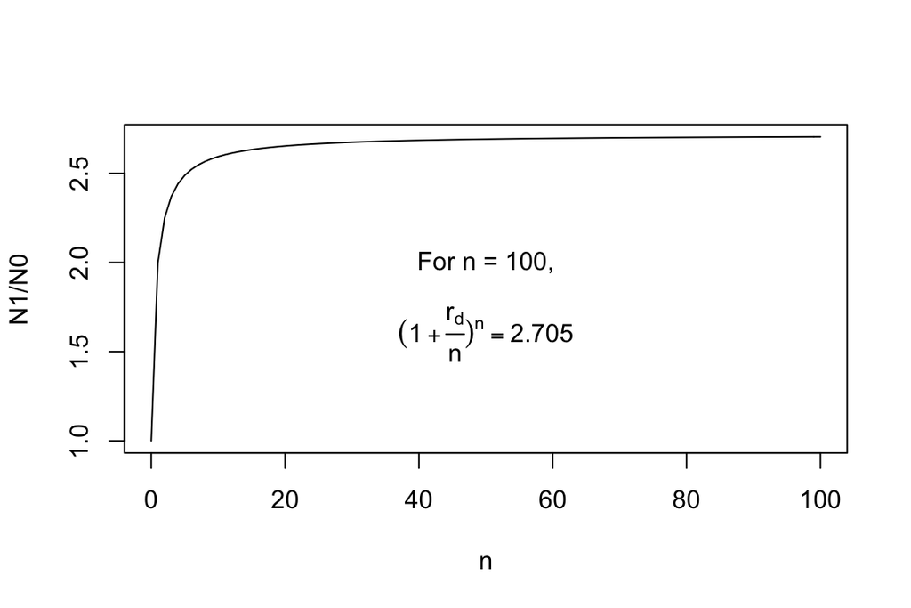

```r
plot(n, N1/N0, type = "l")
text(50, 2, "For n = 100,")
text(50, 1.6,
     bquote((1+frac("r"["d"],"n"))^"n" == .(round(N1[101]/N0, + 3))))
```

Fig. 1.6: The limit to subdividing reproduction into smaller steps. We can compare this numerical approximation to the true value, $e^1 = 2.718$.

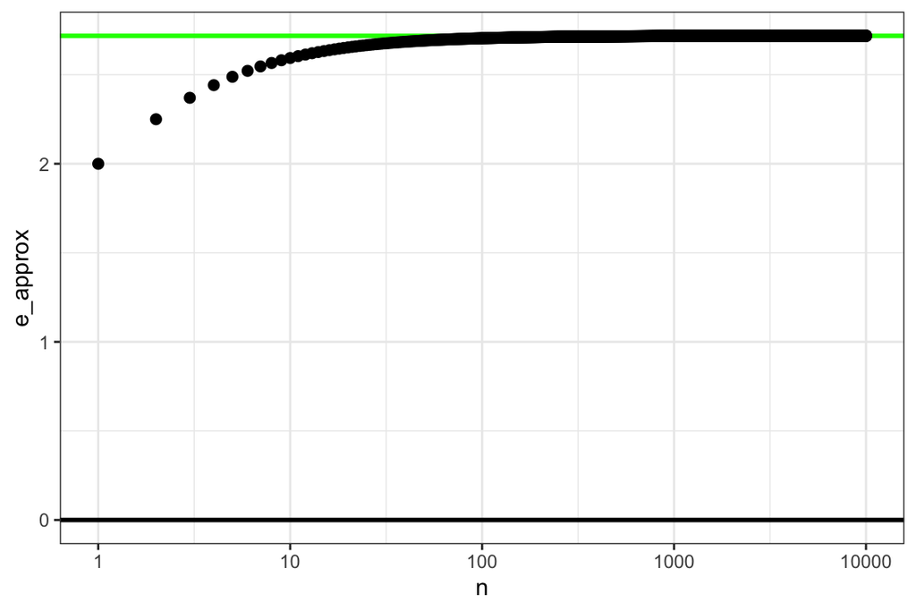

```r
### Casey's version
### I changed the input numbers since computation limits aren't
### much of a big deal
e_df <- data.frame(n = 1:10000, N0 = 1, rd = 1) %>%
  mutate(N1 = N0 * (1 + rd / n)^n,
         e_approx = N1/N0)

ggplot(e_df, aes(x = n, y = e_approx)) +
  theme_bw() +
  geom_hline(yintercept = exp(1), color = 'green', size = 1) +
    ### showing the actual value of e as a target
  geom_hline(yintercept = 0, color = 'black', size = 1) +
    ### throwing on an X axis at y = 0
  geom_point(size = 2) +
  scale_x_log10() ### log scale: easier to see changes in small values of n
```

```r
display_df <- e_df %>%
  filter(n %in% c(10, 100, 1000, 10000)) %>%
  select(n, e_approx) %>%
  mutate(error = round((exp(1) - e_approx) / exp(1), 5))
knitr::kable(display_df)
```

| n | e_approx | error |
| --- | --- | --- |
| 10 | 2.593742 | 0.04582 |
| 100 | 2.704814 | 0.00495 |
| 1000 | 2.716924 | 0.00050 |
| 10000 | 2.718146 | 0.00005 |

#### Projecting a continuous population

We select five different values for $r$: two negative, zero, and two positive. We let $t$ include the integers from 1 to 100. We then use `sapply` to apply our function of continuous exponential growth to each $r$, across all time steps. This results in a matrix where each row is the population size at each time $t$, and each column uses a different $r$.

```r
r <- c(-0.03, -0.02, 0, 0.02, 0.03)
N0 <- 2
t <- 1:100
cont.mat <- sapply(r, function(ri) N0 * exp(ri * t))
```

Next we create side-by-side plots, using both arithmetic and logarithmic scales, and add a legend.

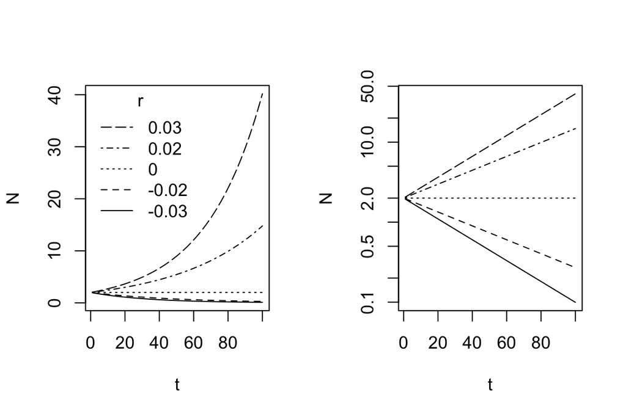

```r
layout(matrix(1:2, nrow = 1))
matplot(t, cont.mat, type = "l", ylab = "N", col = 1)
legend("topleft", paste(rev(r)),
       lty = 5:1, col = 1, bty = "n",
       title = "r")
matplot(t, cont.mat, type = "l", ylab = "N", log = "y", col = 1)
```

### 1.4.3 Doubling (and tripling) time

#### Creating a function for doubling time

We can create a function for this formula, and then evaluate it for different values of $m$ and $r$. For $m = 2$, we refer to this as “doubling time.” When we define the function and include arguments $r$ and $m$, we also set a default value for `m = 2`. This way, we do not always have to type a value for $m$; by default the function will return the doubling time.

```r
m.time <- function(r, m = 2) {
  log(m)/r
}
```

Now we create a vector of $r$, and then use `m.time` to generate a vector of doubling times.

```r
rs <- c(0, 1, 2)
m.time(rs)
```

```
## [1]       Inf 0.6931472 0.3465736
```

```r
# [1]    Inf 0.6931 0.3466
```

Note that R tells us that when $r = 0$, it takes an infinite (`Inf`) amount of time to double. This is what we get when we try to divide by zero!

## 1.6 Modeling with Data: Simulated Dynamics

### 1.6.2 Looking at and collecting the data

```r
names(sparrows)
```

```
## [1] "Year"           "Count"          "ObserverNumber"
```

```r
# [1] "Year"           "Count"          "ObserverNumber"
attach(sparrows) # this allows names to be called directly without sparrows$xyz
```

Now we plot these counts through time (Fig. 1.8).

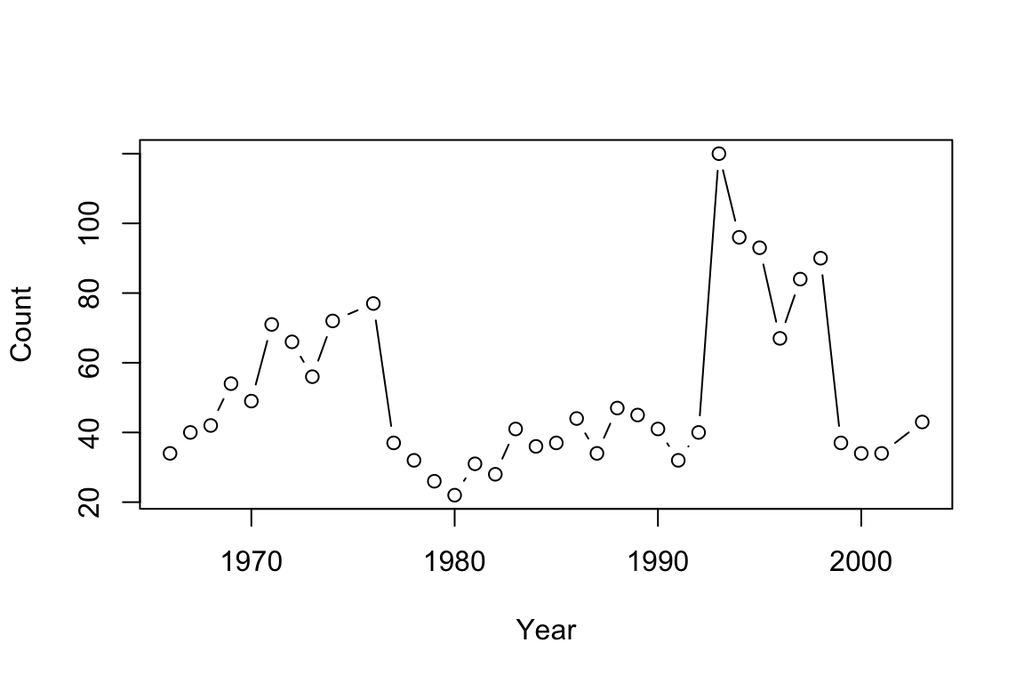

```r
plot(Count ~ Year, type = "b")
```

```r
obs.R <- Count[-1]/Count[-length(Count)] # allows division by previous count value
```

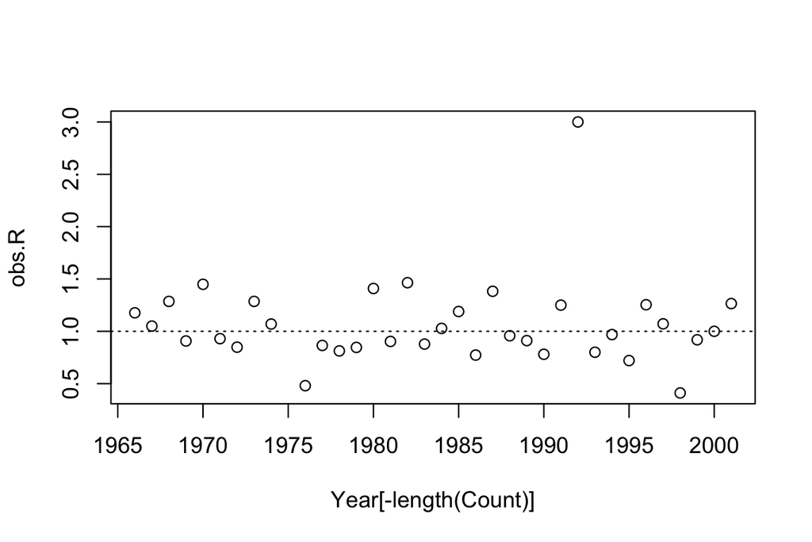

```r
plot(obs.R ~ Year[-length(Count)]) # removing last value
abline(h = 1, lty = 3)
```

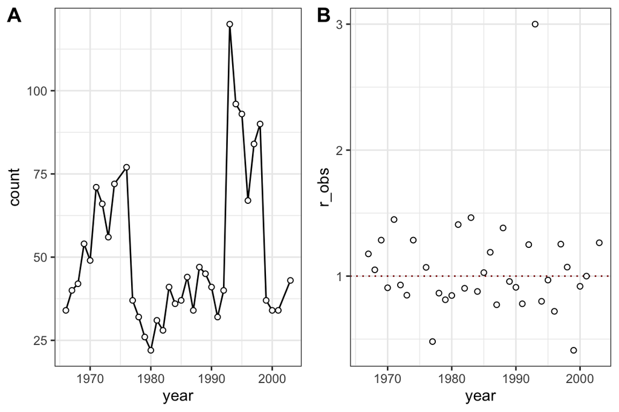

```r
### Casey's version
data(sparrows) ### load data from the primer package

### use the sparrows dataframe to determine R for each interval
obs_r_df <- sparrows %>%
  setNames(tolower(names(.))) %>% # need (.) because names() function doesn't know to call dataframe
  mutate(t = 0:(n() - 1),
         r_obs = count / lag(count)) # divides by count 1 year before

### replicate Fig. 1.8
fig1_8a <- ggplot(obs_r_df, aes(x = year, y = count)) +
  theme_bw() +
  geom_line() +
  geom_point(shape = 21, fill = 'white')

fig1_8b <- ggplot(obs_r_df, aes(x = year, y = r_obs)) +
  theme_bw() +
  geom_hline(yintercept = 1, linetype = 'dotted', color = 'darkred') +
  geom_point(shape = 21, fill = 'white')

fig1_8 <- cowplot::plot_grid(fig1_8a, fig1_8b, labels = c('A', 'B'))

print(fig1_8)
```

### 1.6.3 One simulation

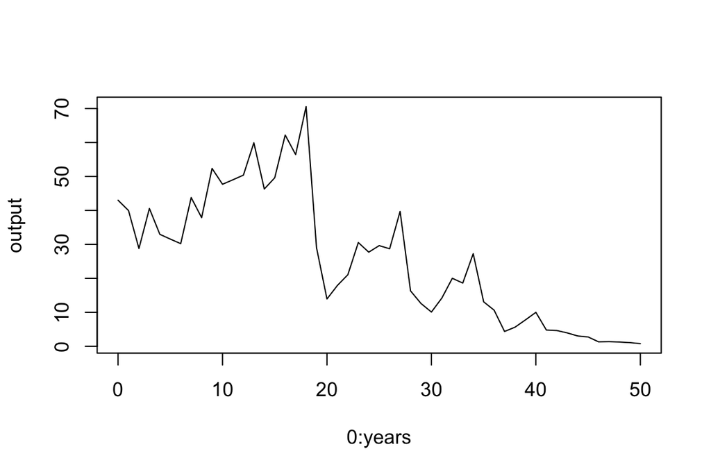

```r
years <- 50
set.seed(3)
sim.Rs <- sample(x = obs.R, size = years, replace = TRUE) # random rampling with replacement

output <- numeric(years + 1) # placeholder with 51 elements

output[1] <- Count[Year == max(Year)] # start with last count provided in observed dataset

for (t in 1:years) output[t + 1] <- {
  output[t] * sim.Rs[t]
}

plot(0:years, output, type = "l")
```

### 1.6.4 Multiple simulations

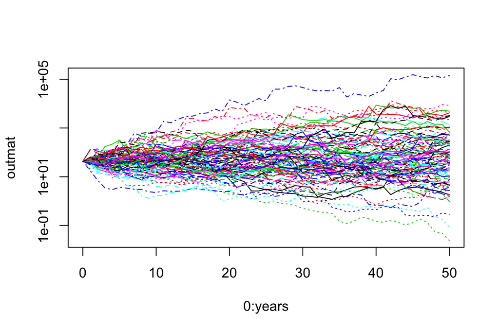

```r
sims = 100
sim.RM <- matrix(sample(obs.R, sims * years, replace = TRUE),
                 nrow = years, ncol = sims)

output[1] <- Count[Year == max(Year)]
outmat <- sapply(1:sims, function(i) { # re-running loop for each simulation (adtl loop)
  for (t in 1:years) output[t + 1] <- output[t] * sim.RM[t, i]
  output
  })

matplot(0:years, outmat, type = "l", log = "y")
```

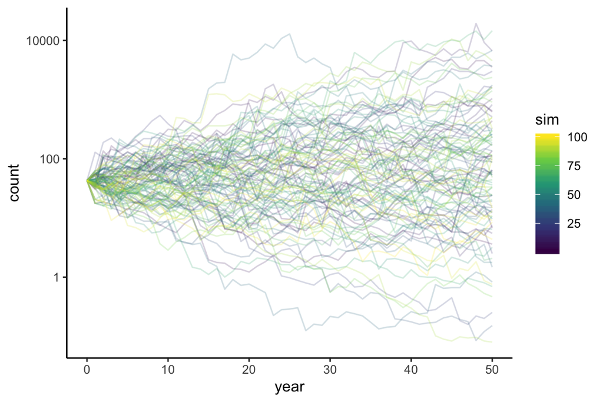

```r
### Casey's version
years <- 50
sims  <- 100
set.seed(3)

### use the sparrows dataframe to determine R for each interval (same as above)
obs_r_df <- sparrows %>%
  setNames(tolower(names(.))) %>%
  mutate(r_obs = count / lag(count)) %>%
  filter(!is.na(r_obs))

sims_df <- crossing(year = 0:years,
                    sim  = 1:sims) %>% # similar to expand.grid(), get all combinations but in 2 column df
  mutate(sim_r = sample(obs_r_df$r_obs, n(), replace = TRUE),
           ### sample r for all combos of year and sim at once
         count = ifelse(year == 0, last(obs_r_df$count), NA))
           ### start N where observed ended, i.e. count is 43

### unfortunately we need to do this with a loop since each count value
### depends stochastically on the one before
sims_df2 <- sims_df %>%
  group_by(sim)
for(yr in 1:years) { ### yr <- 1
  sims_df2 <- sims_df2 %>%
    mutate(count = ifelse(year == yr, lag(count) * sim_r, count))
}
sims_df2 <- sims_df2 %>%
  ungroup()

ggplot(sims_df2, aes(x = year, y = count, color = sim)) +
  theme_classic() +
  geom_line(aes(group = sim), alpha = .2) +
  scale_color_viridis_c() +
  scale_y_log10()
```

### 1.6.5 Many simulations, with a function

```r
PopSim <- function(Rs, N0, years = 50, sims = 10) {
  sim.RM = matrix(sample(Rs, size = sims * years, replace = TRUE),
                  nrow = years, ncol = sims)
  output <- numeric(years + 1)
  output[1] <- N0
  outmat <- sapply(1:sims, function(i) {
    for (t in 1:years) output[t + 1] <- round(output[t] * sim.RM[t, i], 0)
    output
  })
  return(outmat)
}
```

```r
system.time(output <- PopSim(Rs = obs.R, N0 = 43, sims = 1000))
```

```
##    user  system elapsed
##   0.105   0.003   0.189
```

```r
#  user  system elapsed
# 0.404   0.004   0.407
```

This tells me that it took less than half a second to complete 1000 simulations. That helps me understand how long 100,000 simulations might take. We also check the dimensions of the output, and they make sense.

```r
dim(output)
```

```
## [1]   51 1000
```

```r
# [1] 51 1000
```

```r
### Casey's function slow but readable
pop_sim_multi <- function(r_vec = 1.1, n_0 = 100, years = 50, sims = 20) {
  sims_df <- crossing(year = 0:years,
                      sim  = 1:sims) %>%
    mutate(sim_r = sample(r_vec, size = n(), replace = TRUE),
           count = ifelse(year == 0, n_0, NA))

  sims_df2 <- sims_df %>%
    group_by(sim)
  for(yr in 1:years) { ### yr <- 1
    sims_df2 <- sims_df2 %>%
      mutate(count = ifelse(year == yr, lag(count) * sim_r, count))
  }
  sims_df2 <- sims_df2 %>%
    ungroup()
  return(sims_df2)
}

system.time(pop_output <- pop_sim_multi(r_vec = obs_r_df$r_obs, n_0 = 43, years = 50, sims = 1000))
```

```
##    user  system elapsed
##   5.001   0.716   8.249
```

```r
  #  user  system elapsed
  # 5.244   0.586   9.090
```

```r
nums <- c(1:40, NA)

calc_geom_mean <- function(num_vec) {
  x <- prod(num_vec, na.rm = TRUE)
  n <- length(num_vec[!is.na(num_vec)])
  y <- x^(1/n)
  print(x)
  return(y)
}

x <- calc_geom_mean(num_vec = nums)
```

```
## [1] 8.159153e+47
```

```r
### Casey's function(s) higher performance
pop_sim_one <- function(r_vec, n_0, years = 50, print = FALSE) {
  ### resample the r vector
  r_vec_rand <- sample(r_vec, size = years, replace = TRUE)
  sim_vec <- vector('numeric', length = years + 1)
  sim_vec[1] <- n_0
  ### loop over years to determine pop in each year for this set of r
  for(yr in 1:years) { ### yr <- 1
    sim_vec[yr + 1] <- round(sim_vec[yr] * r_vec_rand[yr])
  }
  if(print == TRUE) print(sim_vec)
  ### return the simulated vector - no need for year (assume in order) and
  ### no need for r (unobservable anyway)

  return(sim_vec)
}

system.time(pop_output <- pop_sim_one(r_vec = obs_r_df$r_obs, n_0 = 43, years = 50))
```

```
##    user  system elapsed
##   0.015   0.000   0.019
```

```r
  #  user  system elapsed
  # 0.015   0.002   0.026

pop_sim_many <- function(r_vec, n_0, years, sims) {
  ### use lapply() instead of a for loop (or sapply in the orig function)
  sim_list <- lapply(1:sims, FUN = function(x) {
    pop_sim_one(r_vec = r_vec, n_0 = n_0, years = years)
  })
  sims_mat <- matrix(unlist(sim_list), nrow = years + 1, ncol = sims)
}

system.time({
  pop_output_cco <- pop_sim_many(r_vec = obs_r_df$r_obs,
                                 n_0 = 43, years = 50, sims = 1000)
  })
```

```
##    user  system elapsed
##   0.096   0.002   0.162
```

```r
  #  user  system elapsed
  # 0.096   0.015   0.238
```

### 1.6.6 Analyzing results

```r
N.2053 <- output[51, ]
summary(N.2053, digits = 6)
```

```
##    Min. 1st Qu.  Median    Mean 3rd Qu.    Max.
##       0      14      66    1160     294  332236
```

```r
# Min.  1st Qu.   Median     Mean  3rd Qu.     Max.
#  0.0     14.0     66.0   1124.6    291.8 332236.0
```

```r
quantile(N.2053, prob = c(0.0275, 0.975))
```

```
##  2.75%  97.5%
##    0.0 6860.7
```

```r
# 2.75% 97.5%
#     0  5967
```

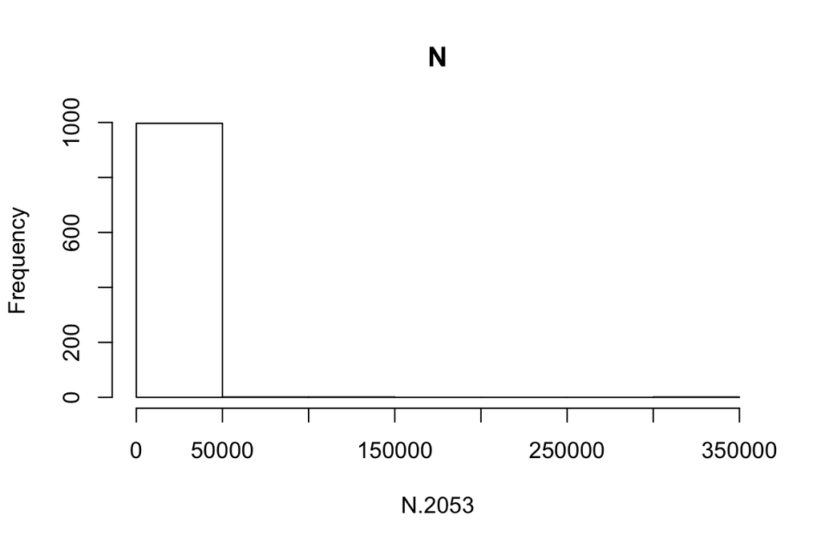

```r
hist(N.2053, main = "N")
```

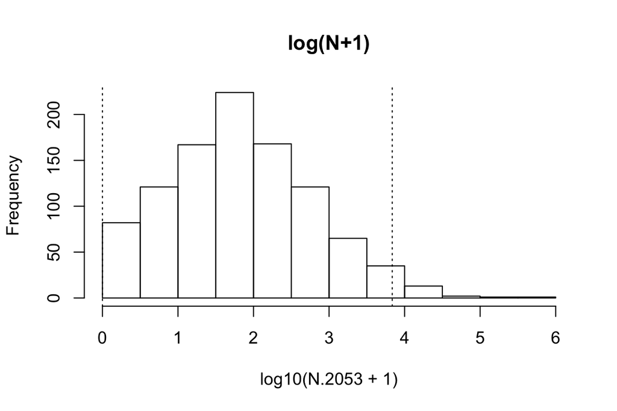

```r
hist(log10(N.2053 + 1), main = "log(N+1)")
abline(v = log10(quantile(N.2053, prob = c(0.0275, 0.975)) + 1),
       lty = 3)
```

```r
logOR <- log(obs.R)
n <- length(logOR)
t.quantiles <- qt(c(0.025, 0.975), df = n - 1)

se <- sqrt(var(logOR)/n)
CLs95 <- mean(logOR) + t.quantiles * se

R.limits <- exp(CLs95)
R.limits
```

```
## [1] 0.8967762 1.1301703
```

```r
# [1] 0.8968 1.1302

N.Final.95 <- Count[Year == max(Year)] * R.limits^50
round(N.Final.95)
```

```
## [1]     0 19528
```

```r
# [1] 0 19528
```

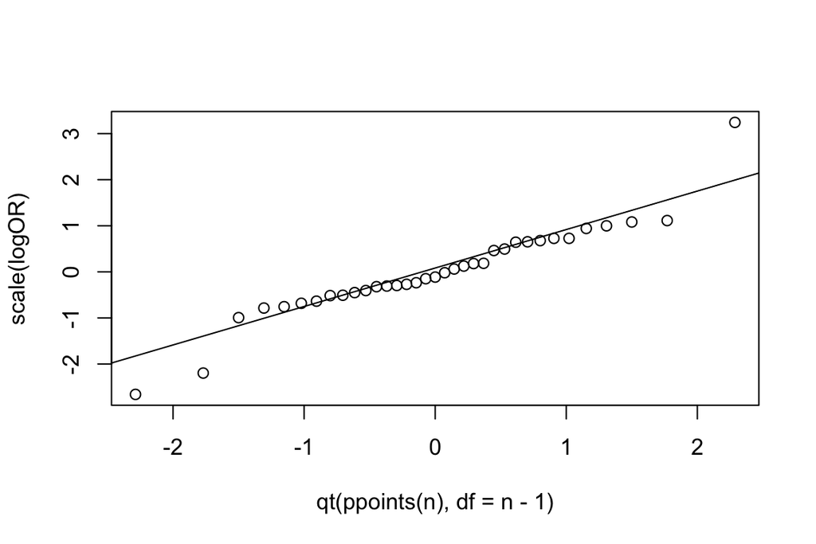

```r
qqplot(qt(ppoints(n), df = n - 1), scale(logOR))
qqline(scale(logOR))
```

```r
### Casey's outputs

### Look at last row for predictions at the end of all sims
n_2053_cco <- pop_output_cco[51, ]
summary(n_2053_cco, digits = 6)
```

```
##     Min.  1st Qu.   Median     Mean  3rd Qu.     Max.
##      0.0     13.0     67.0   1000.0    287.2 100911.0
```

```r
# Min.  1st Qu.   Median     Mean  3rd Qu.     Max.
# 0.00    13.75    59.00   740.09   257.50 67456.00
### mean and median are very different - skewed right

quantile(n_2053_cco, prob = c(0.0275, 0.975))
```

```
##    2.75%    97.5%
##    0.000 7794.875
```

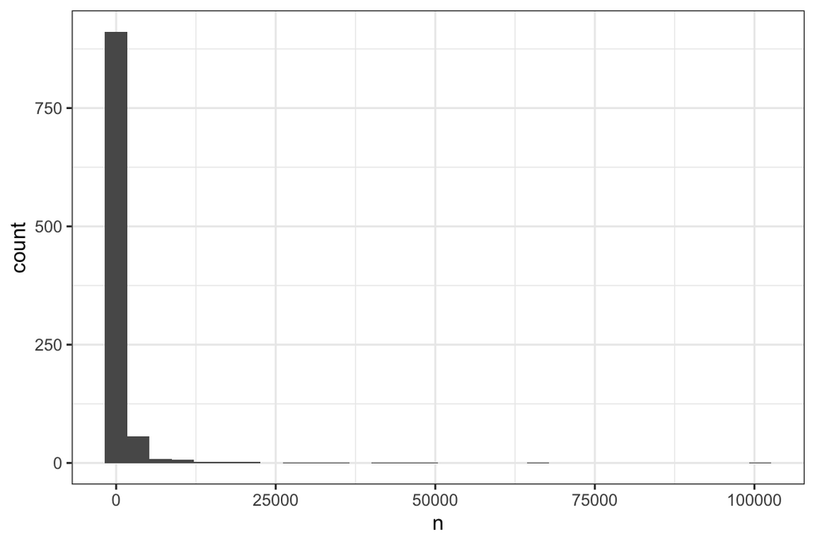

```r
# 2.75%   97.5%
#  0.00 5763.65

# hist(n_2053_cco, main = "N")
# hist(log10(n_2053_cco + 1), main = "log(N+1)")
# abline(v = log10(quantile(n_2053_cco, prob = c(0.0275, 0.975)) + 1),
#        lty = 3)
### put into dataframe for ggplot
df_2053 <- data.frame(n = n_2053_cco) %>%
  mutate(log_nplus1 = log(n + 1))

ggplot(df_2053) +
  theme_bw() +
  geom_histogram(aes(x = n)) # +
```

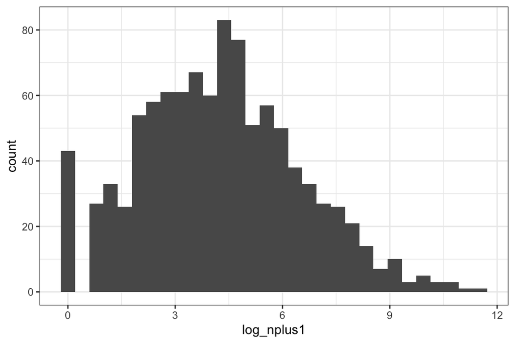

```r
  # scale_x_log10()
ggplot(df_2053) +
  theme_bw() +
  geom_histogram(aes(x = log_nplus1))
```

```r
### Casey's continuation - looking at projections using log R

### recreate obs R vector just in case
log_r_vec <- sparrows %>%
  setNames(tolower(names(.))) %>%
  mutate(r_obs = count / lag(count)) %>%
  filter(!is.na(r_obs)) %>%
  .$r_obs %>%
  log()

### use qt() to find the 2.5 and 97.5 quantiles of the distribution
### with degrees of freedom based on obs_r_vec
t_quants <- qt(c(0.025, 0.975), df = length(log_r_vec) - 1)

### calc standard error as std dev/sqrt(n) or sqrt(var / n)
log_r_se <- sd(log_r_vec) / sqrt(length(log_r_vec))
log_r_se <- sqrt(var(log_r_vec) / length(log_r_vec))
# [1] 0.05691178

### calc 95% confidence intervals: mean +/- the (T values times the standard error)
log_r_95ci <- mean(log_r_vec) + t_quants * log_r_se

r_95ci <- exp(log_r_95ci)
# [1] 0.8967762 1.1301703

n_95 <- last(sparrows$Count) * r_95ci^50
round(n_95)
```

```
## [1]     0 19528
```

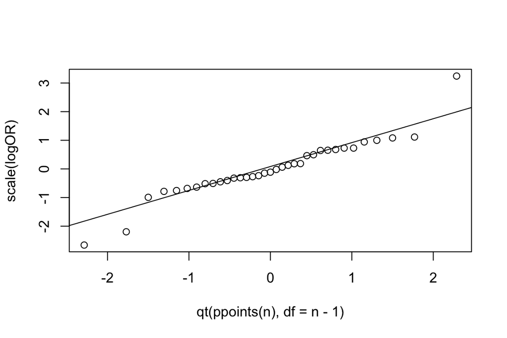

```r
# [1] 0 19528

qqplot(qt(ppoints(n), df = n - 1), scale(logOR))
qqline(scale(logOR))
```

## End of chapter questions

### 1.1. Geometric growth Analyze the following data, relying on selected snippets of previous code.

1. In the years 1996 through 2005, lily population sizes are $N = 150, 100, 125, 200, 225, 150, 100, 175, 100, 150$. Make a graph of population size versus time.
2. Calculate $R$ for each year; graph $R$ vs. time.
3. Calculate arithmetic and geometric average growth rates of this population.
4. Based on the appropriate average growth rate, what would be the expected population size in 2025? What would the estimated population size be if you used the inappropriate mean? Do not use simulation for this.
5. Given these data, develop simulations as above with the user-defined function, `PopSim`. Describe the distribution of projected population sizes for 2010.

### 1.2. Doubling Time

1. Derive the formula for doubling time in a population with continuous exponential growth.
2. What is the formula for tripling time?
3. If we are modeling humans or *E. coli*, would a model of geometric, or exponential growth be better? Why?
4. If an *E. coli* population grew from 1000 cells to 2 × 10<sup>9</sup> cells in 6 h, what would its intrinsic rate of increase be? Its doubling time?

### 1.3. Human Population Growth

1. There were about 630 million people on the planet in 1700, and 6.3 billion in 2003 [33]. What was the intrinsic rate of increase, r?
2. Graph the model of human population size population size from 1700 to 2020.
3. Add points on the graph indicating the population doublings from 1700 onward.
4. What will prevent humans from outweighing the planet by the end of this century? What controls human population growth? Do these controls vary spatially across the planet? See Cohen [33] to get going.

### 1.4. R functions

Find the R functions in Chapter 1. Demonstrate their uses.